# p8105_hw2_wz2506

Weiran Zhang

10/2/2019

##Problem 1

```r
getwd()
```

```
## [1] "/Users/weiranzhang/p8105_hw2_wz2506"
```

```r
trashwheel = read_excel(path =
               "./hw2_data/Trash-Wheel-Collection-Totals-8-6-19.xlsx",
             sheet="Mr. Trash Wheel", na = "") %>% ##load data and specify the sheet in Excel file
  drop_na(Dumpster) %>% ##omit rows that do not include dumpster-specific data
  select(-...15, -...16, -...17) %>% ##omit non-data entries
  mutate(`Sports Balls` = as.integer(`Sports Balls`)) ##convert Sports Balls to integer variable
```

```
## * `` -> ...15
## * `` -> ...16
## * `` -> ...17
```

```r
view(trashwheel)
```

2017 precipitation data

```r
precp2017 = read_excel(path =
               "./hw2_data/Trash-Wheel-Collection-Totals-8-6-19.xlsx"
               ,sheet="2017 Precipitation", na="", skip=1) %>% ##read and clean data in 2017 Precipitation sheet file
  drop_na('Total') %>% ## omit rows without precipitation data
  mutate(year = "2017") ##add a variable year

view(precp2017)
```

2018 precipitation data

```r
precp2018 = read_excel(path = "./hw2_data/Trash-Wheel-Collection-Totals-8-6-19.xlsx"
,sheet="2018 Precipitation", na="", skip=1) %>% ####read and clean data in 2018 Precipitation sheet file
  drop_na('Total') %>% ## omit rows without precipitation data
  mutate(year = "2018") ##add a variable year

view(precp2018)
```

```r
join_data =
  left_join(precp2017, precp2018, by = "Month")%>% ##combine data sets
  mutate(Month = month.name[Month]) ##convert month to character variable

view(join_data)
```

```r
##getting median of sports balls in 2017
trashwheelnew = trashwheel %>%
  filter(Year == "2017")

median(pull(trashwheelnew, `Sports Balls`))
```

```
## [1] 8
```

`There are 344 observations in the cleaned trash wheel dataset and 13 observations in the compiled precipitation dataset. Key variables in cleaned trash wheel dataset are weight, volume, plastic bottles, polystyrene, cigarette butts, glass bottles, grocery bags, chip bags, sports balls and homes powered. Key variables in compiles precipitation dataset are total precipitations in 2017 and each months and 2018 and each months. According to the compiled precipitation dataset, the total precipitation in 2018 is 70.33. Median number of the sports balls in a dumpster in 2017 is 8.`

##Problem 2

```r
getwd()
```

```
## [1] "/Users/weiranzhang/p8105_hw2_wz2506"
```

```r
polsmonth = read_csv(file = "./hw2_data/fivethirtyeight_datasets/pols-month.csv") %>% ##read data
  separate(mon, c("year","month","day"), sep = "-") %>% ##break mon variable
  mutate(president = ifelse(prez_gop > 0, "gop", "dem")) %>% ##president variable taking values of prez_gop and prez_dem then indicate whether dem or gop.
  select(- prez_gop,
         - prez_dem) %>% ##remove prez_gop and prez_dem variables
  mutate(month = as.character(month)) %>%
  mutate(month = replace(month, month == '01', 'Jan'),
         month = replace(month, month == '02', 'Feb'),
         month = replace(month, month == '03', 'Mar'),
         month = replace(month, month == '04', 'Apr'),
         month = replace(month, month == '05', 'May'),
         month = replace(month, month == '06', 'Jun'),
         month = replace(month, month == '07', 'Jul'),
         month = replace(month, month == '08', 'Aug'),
         month = replace(month, month == '09', 'Sep'),
         month = replace(month, month == '10', 'Oct'),
         month = replace(month, month == '11', 'Nov'),
         month = replace(month, month == '12', 'Dec'),
  )
view(polsmonth)
```

```r
snp = read_csv(file = "./hw2_data/fivethirtyeight_datasets/snp.csv") %>% ##read data
  separate(date, c("day","month","year"), sep = "/") %>% ##break date variable
  select(year, month, everything()) %>% ##make year and month leading cols
  mutate(month = as.character(month)) %>%
  mutate(month = replace(month, month == '1', 'Jan'),
         month = replace(month, month == '2', 'Feb'),
         month = replace(month, month == '3', 'Mar'),
         month = replace(month, month == '4', 'Apr'),
         month = replace(month, month == '5', 'May'),
         month = replace(month, month == '6', 'Jun'),
         month = replace(month, month == '7', 'Jul'),
         month = replace(month, month == '8', 'Aug'),
         month = replace(month, month == '9', 'Sep'),
         month = replace(month, month == '10', 'Oct'),
         month = replace(month, month == '11', 'Nov'),
         month = replace(month, month == '12', 'Dec'),
  )
view(snp)
```

```r
unemployment = read_csv(file =
                  "./hw2_data/fivethirtyeight_datasets/unemployment.csv")
unemploymentlong = gather(unemployment, month, measurement, Jan:Feb:Mar:Apr:May:Jun:Jul:Aug:Sep:Oct:Nov:Dec, factor_key = TRUE)
polssnp = left_join(polsmonth, snp, by = c("year", "month"))

join_data2 = left_join(polssnp, unemploymentlong, by = "month")
view(join_data2)
```

```r
##get dimensions of data
dim(polsmonth)
```

```
## [1] 822  10
```

```r
dim(snp)
```

```
## [1] 787   4
```

```r
dim(unemployment)
```

```
## [1] 68 13
```

```r
dim(join_data2)
```

```
## [1] 94588    14
```

`Dimensions for pols-month is 822rows*10cols(variables), for snp is 787*4, for unemployment is 68*13, for unemploymentlong is 816*3, for joined dataset is 94588*14. Range of year for pols-month dataste is 1947-2015, for snp dataset is 1950-2015, for unemployment is 1948-2015. The Key variables are year, month, day, close data, measurement data and parties presidents belong to.`

##Problem 3

```r
babynames = read_csv(file = "./hw2_data/Popular_Baby_Names.csv") %>%##read data
  distinct(babynames) %>%##remove duplicate rows
  mutate(Ethnicity = replace(Ethnicity, Ethnicity == 'ASIAN AND PACI', 'ASIAN AND PACIFIC ISLANDER'),
         Ethnicity = replace(Ethnicity, Ethnicity == 'BLACK NON HISP', 'BLACK NON HISPANIC'),
         Ethnicity = replace(Ethnicity, Ethnicity == 'WHITE NON HISP', 'WHITE NON HISPANIC')
  ) ##addressing the names of categorical predictor problem
view(babynames)

##what does it mean by "categorical predictor and the case structure of string variables changed over time"??
```

```r
##table 1
babynamestable1 = babynames %>%
  select(everything(), -Count) %>%
  filter(Gender == "FEMALE", `Child's First Name` == "Olivia") %>%
  distinct()

table1 = pivot_wider(babynamestable1,
            names_from = `Year of Birth`,
            values_from = Rank) %>%
  select(-`Child's First Name`, -Gender)
view(table1)


##table 2
babynamestable2 = babynames %>%
  select(everything(), -Count) %>%
  filter(Gender == "MALE", Rank == "1") %>%
  distinct()

table2 = pivot_wider(babynamestable2,
            names_from = `Year of Birth`,
            values_from = `Child's First Name`) %>%
  select(-Rank, -Gender)
view(table2)
```

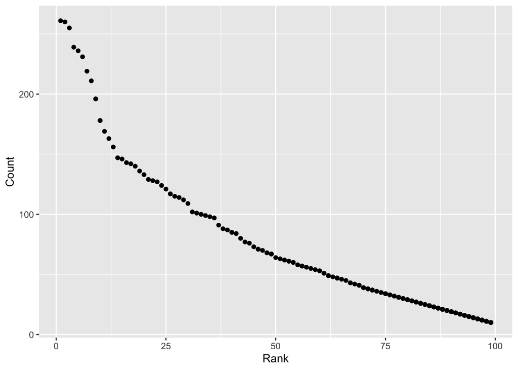

```r
##scatterplot
babynamesscatterplot = babynames %>%
  filter(Gender == "MALE", `Year of Birth` == "2016", Ethnicity == "WHITE NON HISPANIC") %>%
  distinct()

view(babynamesscatterplot)


ggplot(babynamesscatterplot, aes(x = Rank, y = Count)) +
  geom_point()
```